# Los pingüinos molan

Los pingüinos molan

Viendo si con los datos de pingüinos se aprecia la paradoja de Simpson

trabajo BigData

pinguinos

Autorcitos

Afiliación

Bob Dylan (dylanbxxxx@alumni.uv.es)

[Universitat de València](https://www.uv.es)

Patti Smith

Nacho Vegas

Fecha de Publicación

30 de diciembre de 2024

Resumen

## Intro

Vamos a utilizar datos del paquete `palmerpenguins`. El repo del paquete en CRAN está [aquí](https://cran.r-project.org/web/packages/palmerpenguins/index.html), el repo de Github está [aquí](https://github.com/allisonhorst/palmerpenguins) y la página web del paquete está [aquí](https://allisonhorst.github.io/palmerpenguins/).

Los datos se pueden cargar en la memoria de de R/RStudio de esta forma:

**Código**

```r
# install.packages("palmerpenguins")
library(palmerpenguins)
df <- palmerpenguins::penguins
```

El dataset contiene observaciones sobre un conjunto de 344 pingüinos de 3 especies. Hay 8 variables.

## Los pingüinos molan

Vamos a ver una foto de un pingüino:

[figure not shown]

Gráfico 1: Un pingüino chulo: By Robert Elliott of WikiU Film School

Sí, lo pingüinos molan, así que vamos a poner otra foto de pingüinos que tenemos en nuestro PC pero la vamos a poner en el margen:

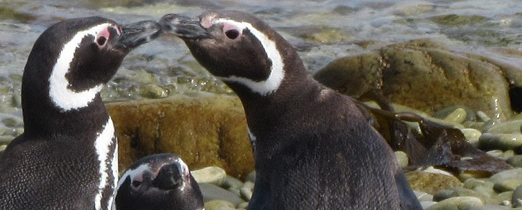

## Algunos gráficos

Bueno pues vamos a hacer algún gráfico, pero claro antes he de cargar los paquetes

**Código**

```r
library(tidyverse)
```

Arreglo los datos

**Código**

```r
#- cojos datos de pingüinos y arreglo un poco
df <- palmerpenguins::penguins %>%
  dplyr::select(species, bill_depth_mm, body_mass_g) %>%
  tidyr::drop_na()
```

### Primer gráfico

**Código**

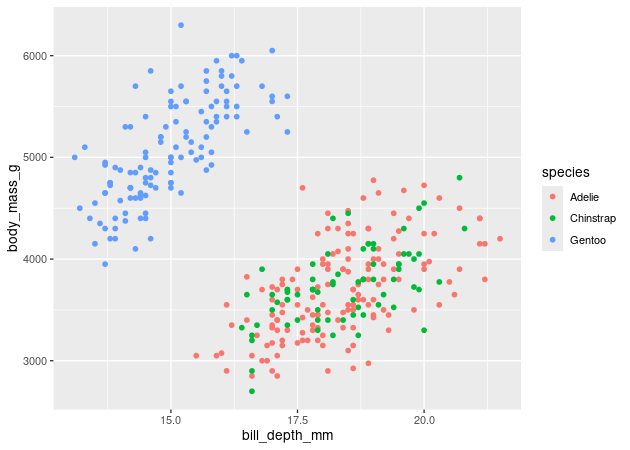

```r
#- primer gráfico
p <- ggplot(data = df,
       mapping = aes(x = bill_depth_mm, y = body_mass_g, color = species)) +
     geom_point()
p
```

### Segundo

**Código**

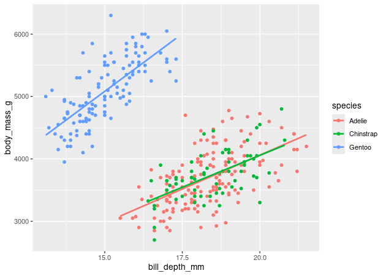

```r
#- segundo gráfico
p <- p + geom_smooth(method = "lm", se = FALSE)

p
```

### El último

**Código**

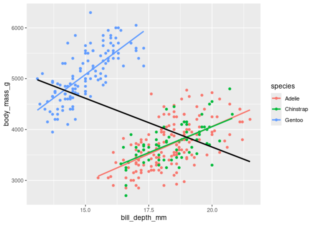

```r
#- tercer gráfico
p + geom_smooth(method = "lm", se = FALSE, color = "black")
```

Con esto acabo mi trabajo para BigData!!

- también podría haber puesto el código y el plot en el margen

**Código**

```r
p + geom_smooth(method = "lm", se = FALSE, color = "black")
```

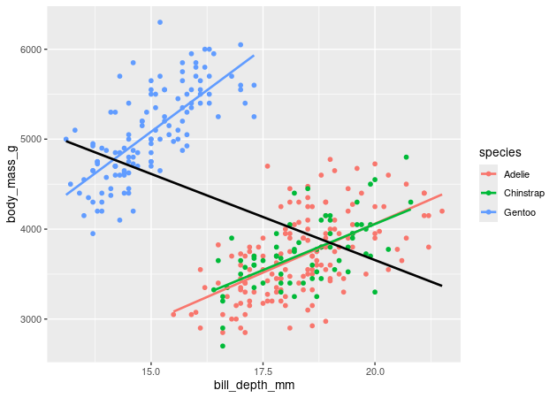